# Project Python Foundations: FoodHub Data Analysis

### **Question 7**: Which are the top 5 restaurants in terms of the number of orders received? [1 mark]

```python
# Write the code here
print(df['restaurant_name'].value_counts().head(5))
```

```
Shake Shack                  219
The Meatball Shop            132
Blue Ribbon Sushi            119
Blue Ribbon Fried Chicken     96
Parm                          68
Name: restaurant_name, dtype: int64
```

#### Observations:

Shake Shack 219 The Meatball Shop 132 Blue Ribbon Sushi 119 Blue Ribbon Fried Chicken 96 Parm 68

### **Question 8**: Which is the most popular cuisine on weekends? [1 mark]

```
                                count
cuisine_type   day_of_the_week
American       Weekday            169
               Weekend            415
Chinese        Weekday             52
               Weekend            163
French         Weekday              5
               Weekend             13
Indian         Weekday             24
               Weekend             49
Italian        Weekday             91
               Weekend            207
Japanese       Weekday            135
               Weekend            335
Korean         Weekday              2
               Weekend             11
Mediterranean  Weekday             14
               Weekend             32
Mexican        Weekday             24
               Weekend             53
Middle Eastern Weekday             17
               Weekend             32
Southern       Weekday              6
               Weekend             11
Spanish        Weekday              1
               Weekend             11
Thai           Weekday              4
               Weekend             15
Vietnamese     Weekday              3
               Weekend              4
```

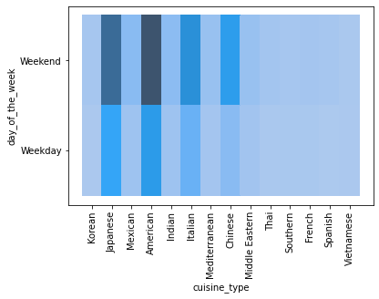

```python
print(df.groupby(['cuisine_type','day_of_the_week'])['cuisine_type'].agg(['count']))


sns.histplot(x = "cuisine_type", y = "day_of_the_week", data = df)
plt.xticks(rotation=90);
plt.show()
```

#### Observations:

Based of the plot and table American food is the most popular on weekends

### **Question 9**: What percentage of the orders cost more than 20 dollars? [2 marks]

```python
greater20 = df[df["cost_of_the_order"]>20]

print('Total orders over 20:', greater20.shape[0])


percentage = (greater20.shape[0] / df.shape[0]) * 100
print( round(percentage, 2), '%', "of the order are above $20")
```

```
Total orders over 20: 555
29.24 % of the order are above $20
```

#### Observations:

29.24 % of the order are above $20

### **Question 10**: What is the mean order delivery time? [1 mark]

```python
average_order_time = df["delivery_time"].mean()  ## Write the appropriate function to obtain the mean delivery time

print(round(average_order_time, 2), "minutes", "is the average time it takes to deliver the food")
```

```
24.16 minutes is the average time it takes to deliver the food
```

#### Observations:

24.16 minutes is the average time it takes to deliver the food

### **Question 11:** The company has decided to give 20% discount vouchers to the top 3 most frequent customers. Find the IDs of these customers and the number of orders they placed. [1 mark]

```python
df["customer_id"].value_counts().head(3).reset_index()
```

|  | index | customer_id |
| --- | --- | --- |
| 0 | 52832 | 13 |
| 1 | 47440 | 10 |
| 2 | 83287 | 9 |

#### Observations:

52832 has 13 orders, 47440 has 10 orders, 83287 has 9 orders These customers should get the %20 discount

### **Question 12**: Perform a multivariate analysis to explore relationships between the important variables in the dataset. (It is a good idea to explore relations between numerical variables as well as relations between numerical and categorical variables) [10 marks]

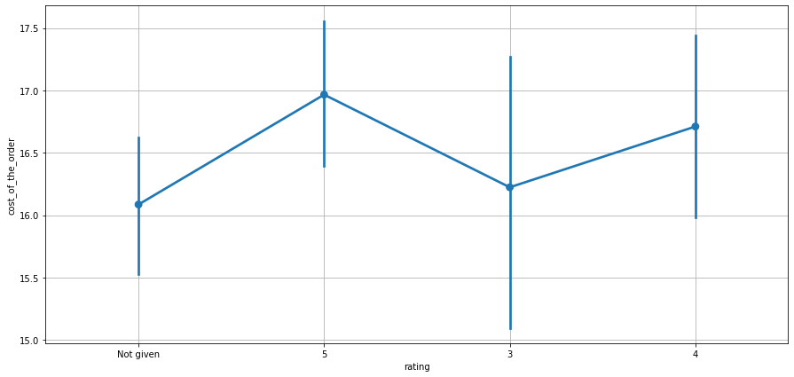

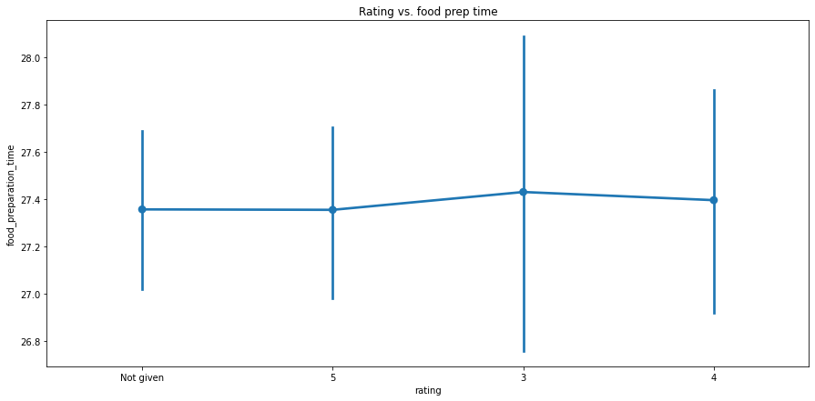

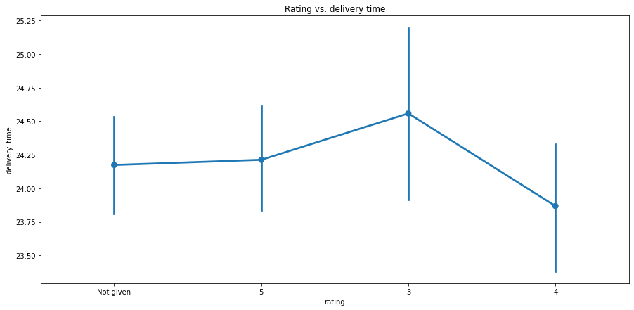

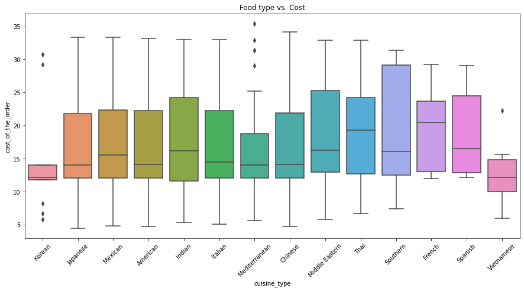

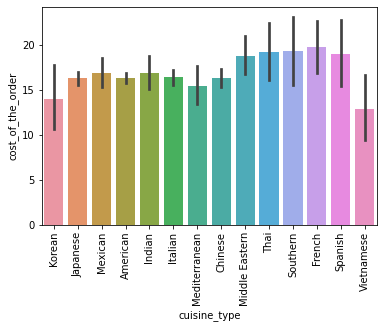

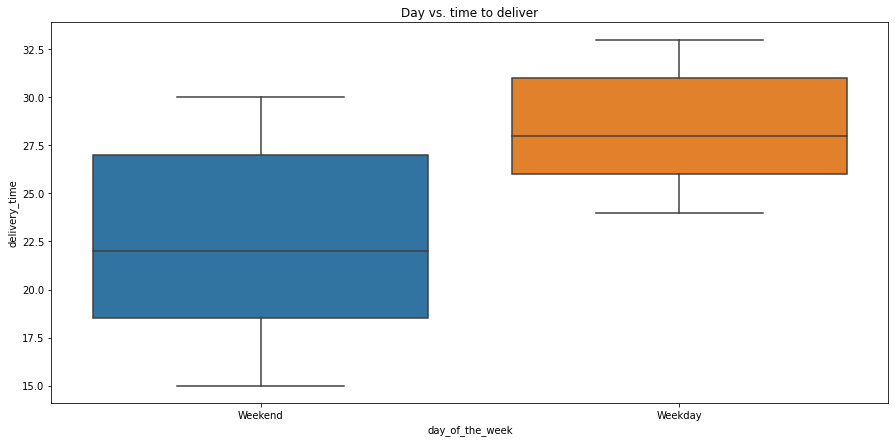

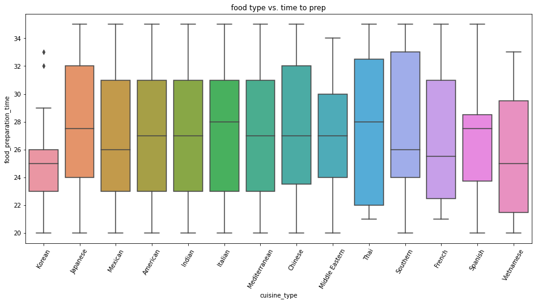

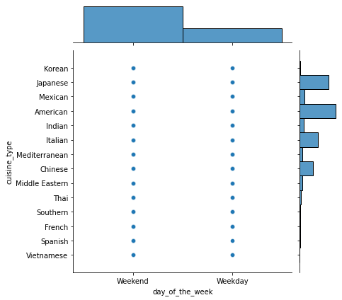

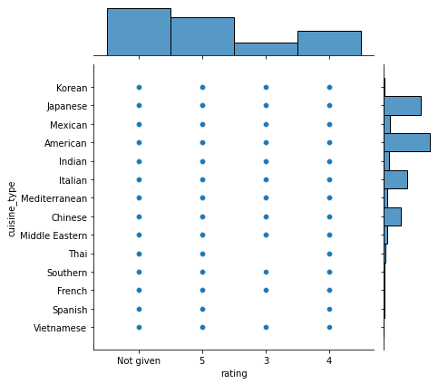

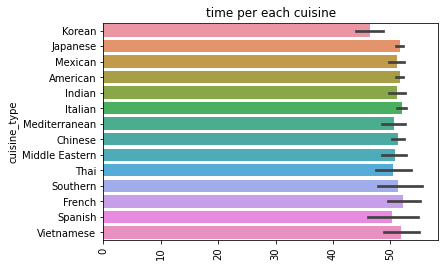

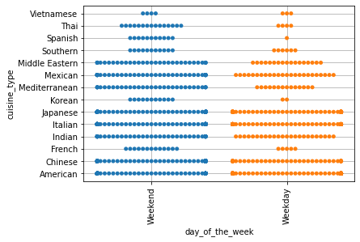

```python
## Ratings vs. Cost of the order
plt.figure(figsize=(15, 7))
sns.pointplot(data = df,x='rating',y= 'cost_of_the_order');
plt.grid()
plt.show()

##Rating vs. Food preparation time
plt.figure(figsize=(15, 7))
sns.pointplot(x = "rating", y = "food_preparation_time", data = df).set(title='Rating vs. food prep time');
plt.show()

##Rating vs. Delivery time
plt.figure(figsize=(15, 7))
sns.pointplot(x = 'rating', y = 'delivery_time', data = df).set(title='Rating vs. delivery time');
plt.show()


##Cuisine vs. Cost of the order
plt.figure(figsize=(15,7))
sns.boxplot(x = "cuisine_type", y = "cost_of_the_order", data = df).set(title='Food type vs. Cost');
plt.xticks(rotation = 45)
plt.show()
sns.barplot(data=df,x="cuisine_type", y="cost_of_the_order");
plt.xticks(rotation=90);
plt.show()

## Day of Week vs. Delivery time
plt.figure(figsize=(15,7))
sns.boxplot(x = "day_of_the_week", y = "delivery_time", data = df).set(title='Day vs. time to deliver');
plt.show()

## Cusine Type vs. Food prep time
plt.figure(figsize=(15,7))
sns.boxplot(x = "cuisine_type", y = "food_preparation_time", data = df).set(title='food type vs. time to prep');
plt.xticks(rotation = 60)
plt.show()

##day of week vs cuisine type
sns.jointplot(x = 'day_of_the_week', y = 'cuisine_type', data = df);
plt.show()


## cuisine type vs rating
sns.jointplot(data = df, x = 'rating', y = 'cuisine_type');
plt.show()

##cuisine type vs time
z = df['delivery_time'] + df['food_preparation_time']
sns.barplot(data=df,y="cuisine_type", x=z).set(title='time per each cuisine');
plt.xticks(rotation=90);
plt.show()

## day of the week and cuisine type
sns.swarmplot( x='day_of_the_week', y = 'cuisine_type', data = df);
plt.grid ()
plt.xticks(rotation=90);
plt.show()
```

Ratings vs. Cost of the order: We can see that the higher rating the higher the cost. A rating of 5 has an average cost of around $17, while a rating of 3 is $16.25

Day of week vs delivery time: we can easily tell that on the weekday, delivery times are much higher, probably due to less driver/demand.

Cuisine Type vs. Food prep time: we can obersve if there is a relaion woth time to make food and the type of food. For example Italian food tends to take more time vs. Korean.

Cuisine tpye vs cost of the order: French food on average is the most expensive and veitnamese is the cheapest.

Rating vs Delivery time: We can see that the lowest rating haveing longer delivery time, meaning delivery time has a correlation to the rating.

Day of week and cuisine type: We can see that weekends are far more popular then weekdays. And that Americam, Japanese, Chinese, and Italian are the most popular.

cuisine tpye vs delivery + prep time: this graph shows the total time to prepare food and deliver. We can see that Korean cuisine is the fastest with around 45 minutes.

### **Question 13:** The company wants to provide a promotional offer in the advertisement of the restaurants. The condition to get the offer is that the restaurants must have a rating count of more than 50 and the average rating should be greater than 4. Find the restaurants fulfilling the criteria to get the promotional offer. [3 marks]

```python
## copy all the ratings that are either 5,4,3
df_rated = df[df['rating'] != 'Not given'].copy()

## casting as integer
df_rated['rating'] = df_rated['rating'].astype('int')

## Create a dataframe that contains the restaurant names with the amount of ratings each have
rest_rating = df.groupby(['restaurant_name'])['rating'].count().reset_index()

## from the restaurant rating we only keep the ones above 50 total ratings
rest_ratings_50 = rest_rating[rest_rating['rating']>50]['restaurant_name']

## getting all the average rating for each restaurant from the rest_rating dataframe
rest_average = rest_rating.groupby(['restaurant_name'])['rating'].mean().reset_index()

## from the restaurant average rating we only want the ones above 4, and store than in a new df
rest_average_4 = rest_average[rest_average['rating']>4]

## print all the ones that have above 4 aberage and are also in the rest_ratings_50 group
rest_average_4[rest_average_4['restaurant_name'].isin(rest_ratings_50)].sort_values(by='rating',ascending = False).reset_index()
```

|  | index | restaurant_name | rating |
| --- | --- | --- | --- |
| 0 | 136 | Shake Shack | 219.0 |
| 1 | 153 | The Meatball Shop | 132.0 |
| 2 | 21 | Blue Ribbon Sushi | 119.0 |
| 3 | 20 | Blue Ribbon Fried Chicken | 96.0 |
| 4 | 109 | Parm | 68.0 |
| 5 | 121 | RedFarm Broadway | 59.0 |
| 6 | 122 | RedFarm Hudson | 55.0 |

### **Question 14:** The company charges the restaurant 25% on the orders having cost greater than 20 dollars and 15% on the orders having cost greater than 5 dollars. Find the net revenue generated by the company across all orders. [3 marks]

```python
def revenue(a):
  if a > 20:
      return a*0.25
  elif a > 5:
      return a*0.15
  else:
      return 0

## .apply allows you to use the function where/when needed
df['revenue'] = df['cost_of_the_order'].apply(revenue)
df.head(4)
total_revenue = df['revenue'].sum()
print(total_revenue, "this is the total revenue generated by the company")
```

```
6166.303 this is the total revenue generated by the company
```

#### Observations:

$6166.303 this is the total revenue generated by the company

### **Question 15:** The company wants to analyze the total time required to deliver the food. What percentage of orders take more than 60 minutes to get delivered from the time the order is placed? (The food has to be prepared and then delivered.) [2 marks]

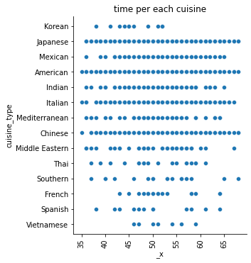

```
10.537407797681771
```

```python
##cuisine type vs time
z = df['delivery_time'] + df['food_preparation_time']
sns.relplot(data=df,y="cuisine_type", x=z).set(title='time per each cuisine');
plt.xticks(rotation=90);
plt.show()
## adding time to make food and deliver in a new column
df['delivery_total_time'] = df['food_preparation_time'] + df['delivery_time']

##loc (row, column)we locate all the deivery times greater than 60 in the delivery total time column
greater_than60 = df.loc[df['delivery_total_time']>60,'delivery_total_time'].count()

## divide by total deliveries
total = df['delivery_total_time'].count()
print(greater_than60/total *100)
```

#### Observations:

Around 10.54% or orders take over 1 hour to get delivered from the time the order is placed.

### **Question 16:** The company wants to analyze the delivery time of the orders on weekdays and weekends. How does the mean delivery time vary during weekdays and weekends? [2 marks]

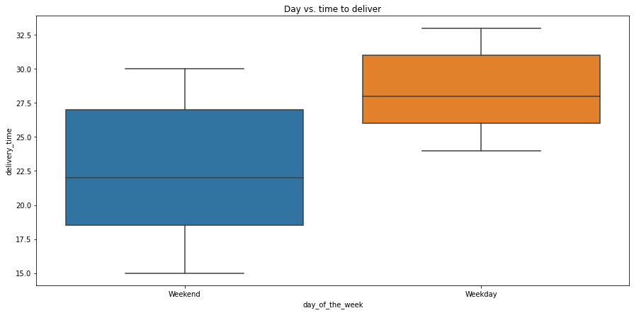

|  | day_of_the_week | delivery_time |
| --- | --- | --- |
| 0 | Weekday | 28.340037 |
| 1 | Weekend | 22.470022 |

```python
plt.figure(figsize=(15,7))
sns.boxplot(x = "day_of_the_week", y = "delivery_time", data = df).set(title='Day vs. time to deliver');
plt.show()

df.groupby(['day_of_the_week'])['delivery_time'].mean().reset_index()
```

#### Observations:

By both the boxplot and the table we can see that weekday delivery time(mean) is much higher then weekend delivery time(mean). 28.35 minutes vs 22.50 minutes